# 4.1 Vizualizacija

December 12, 2016

## Eksploratorna analiza podataka

Eksploratorna analiza podataka - EDA (engl. *exploratory data analysis*): proces analize podatkovnog skupa s ciljem upoznavanja s podacima i donošenjem određenih zaključaka.

- često se identificiraju tri faze procesa:
  - transformacija podataka (engl. *data wrangling*)
  - vizualizacija podataka
  - izrada modela
- ove tri faze nisu slijedne već cirkularne i često se međusobno prožimaju

## Eksploratorna analiza podataka (2)

- osnovni cilj eksploratorne analize
  - odgovoriti na **pitanja** koje smišlja sam analitičar
  - bitna kreativnost i znatiželja; analitičar ima aktivnu ulogu, nije pasivan promatrač podataka
  - pitanja se najčešće tiču **varijabilnosti** podataka i **odnosa** između varijabli

## Eksploratorna analiza podataka (3)

1. Transformacija podataka
   - već smo upoznali učenjem paketa `tidyr`, `dplyr` …
2. Vizualizacija podataka
   - paketi `base`, `grid`, `lattice`, `ggplot2`…
   - tema ove lekcije
3. Modeliranje podataka
   - stvaranje sažetih, konciznih reprezentacija podataka kroz matematičke (i druge modele)
   - upoznati ćemo kasnije

## Vizualizacija podataka u jeziku R

- R se često koristi kao "vizualizacijski alat"
  - brojne mogućnosti za stvaranje profesionalnih, vizualno atraktivnih i lako interpretabilnih grafova.
- osnovna podrška za vizualizaciju - tzv. `base plotting` sustav
  - temelji se na generičkoj funkciji `plot`
  - ukratko - gotovo svaku popularniju klasu proslijedimo navedenoj funkciji što će često rezultirati kompetentnom vizualnom reprezentacijom

## ZADATAK 1 - funkcija `plot`

```r
x <- 1:50
# proslijedite `x` i `x*x` funkciji `plot`
```

## ZADATAK 1 - funkcija `plot`

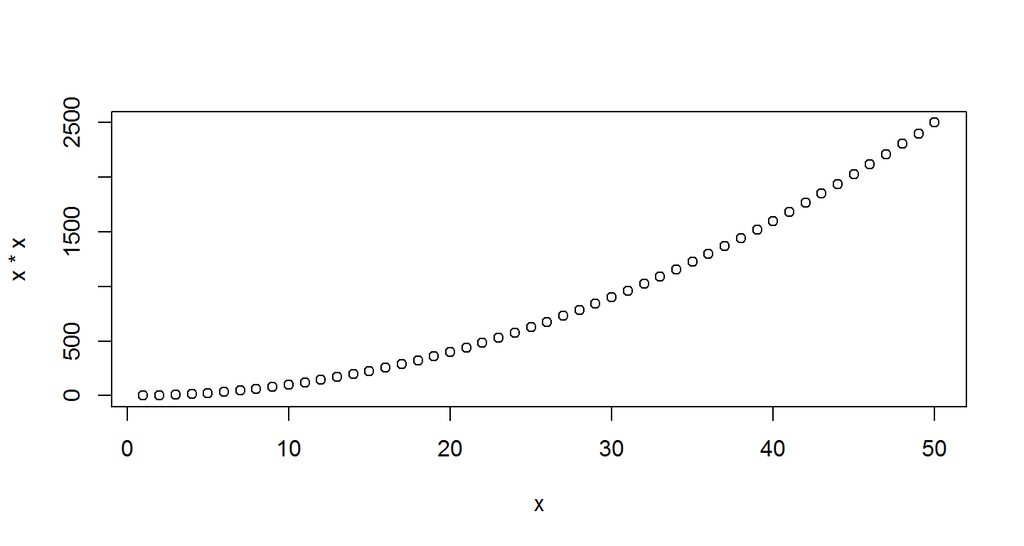

```r
x <- 1:50
# proslijedite `x` i `x*x` funkciji `plot`
plot(x, x*x)
```

## Prednosti i nedostaci funkcije `plot`

Prednosti:

- jednostavno, brzo i učinkovito rješenje
- univerzalnost primjene

Nedostaci:

- grafu se mogu dodavati stvari, ali ne i modificirati
- složenost naglo raste sa porastom zahtjeva nad vizualizacijom

## Dodatni vizualizacijski paketi

Paket `grid`

- bogatiji skup funkcija od osnovne podrške
- nema podršku za "statistike" tako da je često prije vizualizacije potrebno "ručno" računanje vrijednosti koje želimo prikazati

Paket `lattice`

- popularan za stvaranje tzv. "uvjetnih" ("facetiranih") grafova
- prilično autonoman, npr. ima podršku za automatsko stvaranje legendi i sl.
- nije zasnovan na formalnom modelu, teško proširivanje novim funkcionalnostima

## Paket `ggplot2`

- jedan od (općenito!) najpopularnijih R paketa
  - https://www.rdocumentation.org/trends
- zasnovan na tzv. "grafičkoj gramatici" (engl. *grammar of graphics*)
- temelji se na jasno definiranom formalnom modelu
- krivulja učenja inicijalno nešto strmija

## Paket `ggplot2` (2)

- odlična podrška za stvaranje širokog spektra vizualizacija na osnovu koncizne, jasne i sažete sintakse
- omogućuje lako proširenje dodatnim funkcionalnostima
- reimplementiran i u drugim programskim jezicima (paket `ggplot` u *Python-u*, paket `gramm` u *Matlab*-u)

## Grafička gramatika i paket `ggplot2`

Grafička gramatika (engl. *grammar of graphics*) nam daje sljedeće:

- principe koji omogućuju stvaranje i interpretaciju kompleksnih vizualizacija
- naputke što predstavlja "dobro oblikovanu" ili "kvalitetnu" vizualizaciju

Grafove gledamo kao svojevrsne "rečenice" čije razumijevanje ovisi o tome kako pojedine komponente uklopiti u jasnu, razumljivu cjelinu.

Naputak - graf gledati kao sumu "komponenti" od kojih svaka ima svoju ulogu i doprinosi konačnom rezultatu.

- gramatička ispravnost nije garancija kvalitetne rečenice!

## Grafička gramatika i paket `ggplot2` (2)

Za početak, tri osnovne komponente:

1. **podaci** (koje želimo vizualizirati)
2. **estetike** (mapiranja podataka na elemente grafa)
3. **geometrije** (grafička reprezentacija podataka na grafu)

`graf = podaci + mapiranje + geometrija`

## **Podaci** / Estetike / Geometrija

Podatkovni skup je ključna komponenta grafa, predstavlja "ono što želimo vizualizirati".

Podaci su neovisni od ostatka procesa vizualizacije, budući da se isti principi vizualizacije mogu primjeniti nad različitim podatkovnim skupovima).

- ali: karakteristike podatkovnog skupa često direktno utječu na odabir daljnjih koraka.

## Podaci / Estetike / Geometrija

Pojam "estetika" nema veze sa "znanosti o lijepom", ovdje se radi o odabiru kako ćemo na grafu prikazati (mapirati) pojedini stupac.

Uobičajeni princip:

- Kartezijev koordinatni sustav
- osi *x* i *y* kao "osnovne estetike"
- kada "određujemo osnovne estetike grafa" onda kažemo npr. "ovaj stupac/ varijablu stavljam na os x, a ovaj drugi stupac na os y"

## Podaci / Estetike / Geometrija

Osi koordinatnog sustava nisu jedine estetike, ovisno o tome kakav graf crtamo estetike mogu biti:

- boja
- oblik
- prozirnost
- tip uzorka (npr. način crtkanosti linije)
- itd.

Estetiku možemo interpretirati i kao "ono što se objašnjava legendom", pri čemu i osi *x* i *y* možemo smatrati svojevrsnim legendama.

## Podaci / Estetike / Geometrija

"Geometrija" je zapravo "opis kako nešto nacrtati na grafu", tj. sam način vizualne reprezentacije.

To je ono što često zovemo "vrstom" grafa npr.:

- "točkasti graf" (engl. *scatterplot*)
- linijski graf
- stupčasti graf (engl. *bar chart*)
- histogram itd.

Svaka geometrija definira svoje parametre koji se mogu povezati sa estetikama (mapiranjima).

- npr. kod točkastog grafa pored koordinate svake točke možemo birati oblik "točke", boju, prozirnost itd.
- ako je parametar povezan sa estetikom onda će ovisiti o vrijednosti varijable (npr. boja opisuje vrijednost neke kategorije), ako ne onda je fiksiran na razini grafa (npr. želimo "crvene" točke)

## ZADATAK 2 - učitavanje okvira `mtcars`

Koristiti ćemo podatkovni skup `mtcars` koji dolazi sa jezikom R (paket `datasets`). Podatkovni skup možemo učitati u globalnu okolinu uz pomoć funkcije `data`.

```r
# Učitajte podatkovni skup `mtcars` u globalnu okolinu

# proučite okvir `mtcars`  (head, glimpse, ?...)
```

## ZADATAK 2 - učitavanje okvira `mtcars` (2)

```r
# Učitajte podatkovni skup `mtcars` u globalnu okolinu
data(mtcars)

# proučite okvir `mtcars`  (head, glimpse, ?...)
glimpse(mtcars)
```

```
## Observations: 32
## Variables: 11
## $ mpg  <dbl> 21.0, 21.0, 22.8, 21.4, 18.7, 18.1, 14.3, 24.4, 22.8, 19....
## $ cyl  <dbl> 6, 6, 4, 6, 8, 6, 8, 4, 4, 6, 6, 8, 8, 8, 8, 8, 8, 4, 4, ...
## $ disp <dbl> 160.0, 160.0, 108.0, 258.0, 360.0, 225.0, 360.0, 146.7, 1...
## $ hp   <dbl> 110, 110, 93, 110, 175, 105, 245, 62, 95, 123, 123, 180, ...
## $ drat <dbl> 3.90, 3.90, 3.85, 3.08, 3.15, 2.76, 3.21, 3.69, 3.92, 3.9...
## $ wt   <dbl> 2.620, 2.875, 2.320, 3.215, 3.440, 3.460, 3.570, 3.190, 3...
## $ qsec <dbl> 16.46, 17.02, 18.61, 19.44, 17.02, 20.22, 15.84, 20.00, 2...
## $ vs   <dbl> 0, 0, 1, 1, 0, 1, 0, 1, 1, 1, 1, 0, 0, 0, 0, 0, 0, 1, 1, ...
## $ am   <dbl> 1, 1, 1, 0, 0, 0, 0, 0, 0, 0, 0, 0, 0, 0, 0, 0, 0, 1, 1, ...
## $ gear <dbl> 4, 4, 4, 3, 3, 3, 3, 4, 4, 4, 4, 3, 3, 3, 3, 3, 3, 4, 4, ...
## $ carb <dbl> 4, 4, 1, 1, 2, 1, 4, 2, 2, 4, 4, 3, 3, 3, 4, 4, 4, 1, 2, ...
```

## ZADATAK 2 - učitavanje okvira `mtcars` (3)

```r
head(mtcars, 10)
```

```
##                    mpg cyl  disp  hp drat    wt  qsec vs am gear carb
## Mazda RX4         21.0   6 160.0 110 3.90 2.620 16.46  0  1    4    4
## Mazda RX4 Wag     21.0   6 160.0 110 3.90 2.875 17.02  0  1    4    4
## Datsun 710        22.8   4 108.0  93 3.85 2.320 18.61  1  1    4    1
## Hornet 4 Drive    21.4   6 258.0 110 3.08 3.215 19.44  1  0    3    1
## Hornet Sportabout 18.7   8 360.0 175 3.15 3.440 17.02  0  0    3    2
## Valiant           18.1   6 225.0 105 2.76 3.460 20.22  1  0    3    1
## Duster 360        14.3   8 360.0 245 3.21 3.570 15.84  0  0    3    4
## Merc 240D         24.4   4 146.7  62 3.69 3.190 20.00  1  0    4    2
## Merc 230          22.8   4 140.8  95 3.92 3.150 22.90  1  0    4    2
## Merc 280          19.2   6 167.6 123 3.92 3.440 18.30  1  0    4    4
```

## Crtanje prvog `ggplot2` grafa

Odabrani podatkovni skup `mtcars` ima 32 obzervacije i 11 varijabli (sve numeričkog tipa). Zamislimo da želimo vizualizirati odnos dvije varijable, npr. potrošnju (`mpg`, koja predstavlja broj milja koliko auto prijeđe na jedan galon benzina) i težinu (`wt`, izraženu u tisućama funti).

Možemo odabrati sljedeći način mapiranja:

- težina automobila (`wt`) na *x* os grafa
- potrošnja (`mpg`) na *y* os grafa

## Crtanje prvog `ggplot2` grafa

```r
ggplot() +
layer( data = mtcars,                      # 1. podaci
       mapping = aes(x = wt, y = mpg),     # 2. mapiranja / estetike
       geom = "point",                     # 3. geometrija
       stat = "identity",                  # za sada zanemariti
       position = "identity")              # za sada zanemariti
```

## Crtanje prvog `ggplot2` grafa

```r
ggplot() +
layer( data = mtcars,                      # 1. podaci
       mapping = aes(x = wt, y = mpg),     # 2. mapiranja / estetike
       geom = "point",                     # 3. geometrija
       stat = "identity",                  # za sada zanemariti
       position = "identity")              # za sada zanemariti
```

[output not shown]

## Crtanje prvog `ggplot2` grafa

Obično ne koristimo funkciju `layer` već kombinaciju funkcija `ggplot` (u kojoj postavimo "zajedničke" parametre podataka i estetika) te odabrane pomoćne `geom_X` funkcije.

```r
ggplot(mtcars, aes(x = wt, y = mpg)) + geom_point()
```

[output not shown]

## Crtanje prvog `ggplot2` grafa

Postoji i funkcija `qplot` koja zapravo "imitira" sintaksu funkcije `plot` i služi za lakšu prilagodbu paketu `ggplot` za funkcije naviknute na osnovne načine vizualizacije u R-u. Ovu funkciju nećemo koristiti u nastavku uglavnom zbog njezinih ograničenih mogućnosti.

```r
qplot(x = wt, y = mpg, data = mtcars)
```

[output not shown]

## ZADATAK 3 - `shape` estetika

Dodajmo još jednu varijablu u prikazani graf uz pomoć nove estetike - oblika točaka.

```r
# faktorizirajte varijablu `cyl`

# stvorite graf ovisnosti `mpg` o `wt`
# uz mapiranje `cyl` varijable na `shape` estetiku
```

## ZADATAK 3 - `shape` estetika

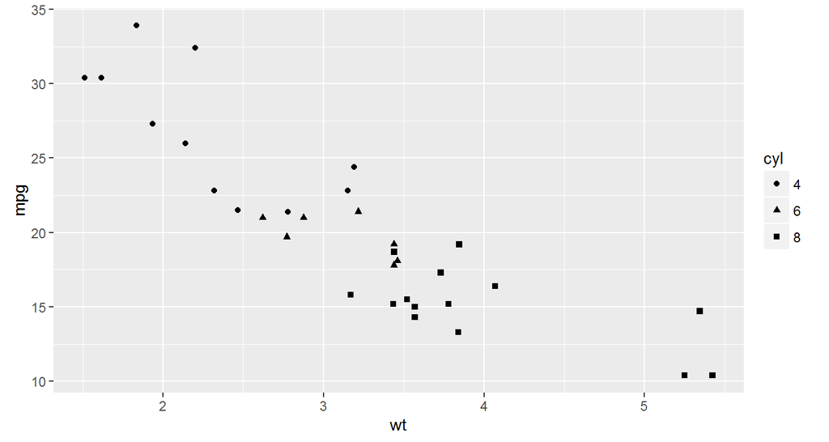

```r
# faktorizirajte varijablu `cyl`
mtcars$cyl <- as.factor(mtcars$cyl)

# stvorite graf ovisnosti `mpg` o `wt`
# uz mapiranje `cyl` varijable na `shape` estetiku
ggplot(mtcars, aes(x = wt, y = mpg, shape = cyl)) + geom_point()
```

## ZADATAK 4 - `color` estetika

Pogledajmo sada estetiku bojr - tj. `color` estetiku.

```r
# stvorite graf ovisnosti `mpg` o `wt`
# ovaj put mapirajte `cyl` varijable na `color` estetiku
```

## ZADATAK 4 - `color` estetika

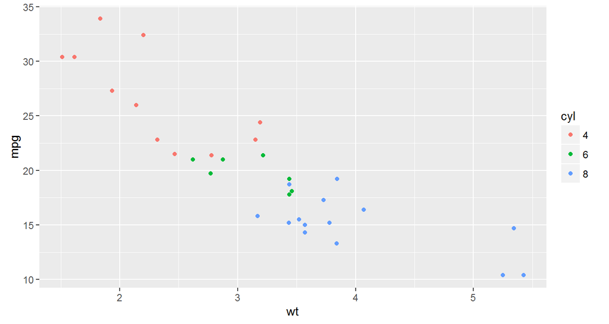

```r
# stvorite graf ovisnosti `mpg` o `wt`
# ovaj put mapirajte `cyl` varijable na `color` estetiku
ggplot(mtcars, aes(x = wt, y = mpg, color = cyl)) + geom_point()
```

## ZADATAK 5 - jedna varijabla na dvije estetike

Istu varijablu slobodno možemo mapirati na više estetika.

```r
# ponovite isti graf, ali varijablu `cyl` mapirajte
# i na `color` i na `shape` estetiku
```

## ZADATAK 5 - jedna varijabla na dvije estetike

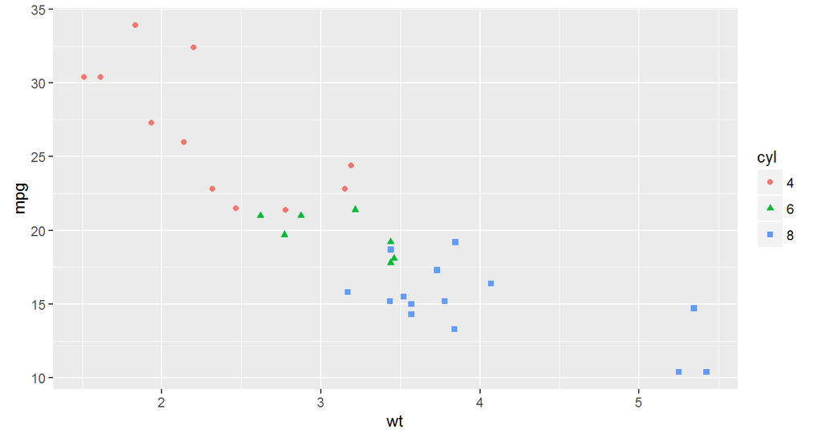

```r
# ponovite isti graf, ali varijablu `cyl` mapirajte
# i na `color` i na `shape` estetiku
ggplot(mtcars, aes(x = wt, y = mpg, color = cyl, shape = cyl)) + geom_point()
```

## Preimenovanje osi, legende, dodavanje naslova

Ukoliko želimo, uz pomoć funkcije `labs` lako primenujemo osi ili legende te dodajemo naslov našem grafu. Sintaksa izgleda ovako:

`ggplot(... ) + ...`

`... + labs(x = "x os", y = "y os", ...`

`title = "Naslov")`

## ZADATAK 6 - funkcija `labs`

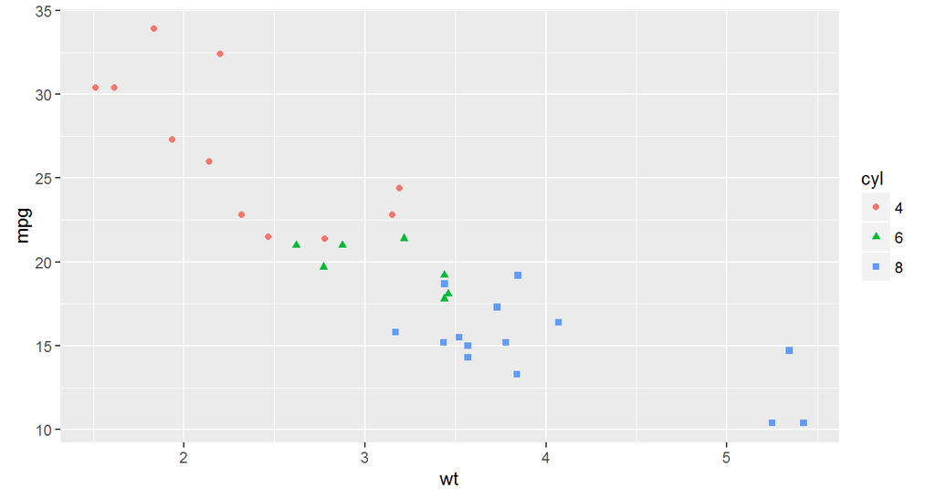

```r
# na sljedećem grafu preimenujte osi i legendu
# te dodajte adekvatni naslov i podnaslov (najbolje nešto što objašnjava graf)
ggplot(mtcars, aes(x = wt, y = mpg, color = cyl, shape = cyl)) + geom_point()
```